# Empirical Network Comparison by Clinical Topic

## Number of distinct treatment comparisons (unipartite edges)

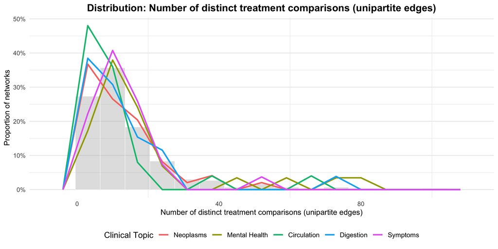

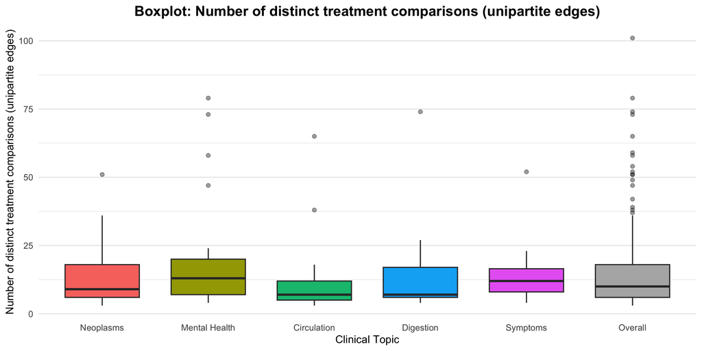

# Conclusion

Using unrounded Benjamini–Hochberg adjusted p-values below 0.10, the Kruskal–Wallis tests selected 5 metrics: Mean treatment degree (Bipartite); Number of trials; Number of arms (bipartite edges); Mean treatment degree (Unipartite); Clustering coefficient (Unipartite). The number of arms differed across Clinical Topics (adjusted $p =$ 0.007), while the number of distinct treatment comparisons did not meet this criterion (adjusted $p =$ 0.190). These omnibus tests do not identify which individual Clinical Topics differ.

In the exploratory comparison of Clinical Topic 02 with the overall empirical distribution, the median number of arms was 28 versus 45 (adjusted $p =$ 0.067). Because each Clinical Topic is contained in the overall sample, these Clinical Topic-versus-overall findings should remain exploratory and should not be interpreted as causal effects of Clinical Topic membership.